# State MSM Profile: **Michigan**

#### South Bend-Mishawaka Metropolitan Statistical Area

The South Bend-Mishawaka MSA overlaps two states: Indiana and Michigan. The Michigan portion of the MSA had 303 MSM, or 0.3% of all MSM in the state and 13.4% of the 2,254 MSM in the MSA. Of 19,935 adult men in the Michigan part of South Bend-Mishawaka, 1.5% were MSM. This was less than the overall percentage of MSM among adult men in the MSA, which was 1.9% of adult men (2,254 out of 116,031).

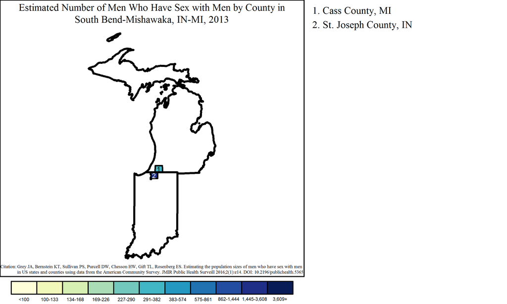

Note: Range cutpoints for the map are based on the distribution of MSM among all counties in the United States.

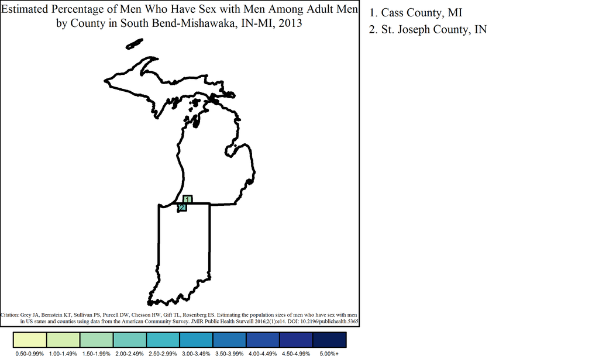